# Week 6 weekend homework

1.Load in the `code_clan_tweets.csv`. Find the number of rows, columns, and lists of all the variable names.

```r
# loading in the the csv
library(readr)
library(tidyverse)
code_clan_tweets <- read_csv("data/code_clan_tweets.csv")
```

```r
# finding the number of rows, columns and lists of all the variable names
nrow(code_clan_tweets)
```

```
[1] 234
```

```r
ncol(code_clan_tweets)
```

```
[1] 27
```

```r
names(code_clan_tweets)
```

```
 [1] "tweet_id"               "user_id"                "created_at"
 [4] "screen_name"            "text"                   "source"
 [7] "display_text_width"     "reply_to_status_id"     "reply_to_user_id"
[10] "reply_to_screen_name"   "is_quote"               "is_retweet"
[13] "favorite_count"         "retweet_count"          "quote_count"
[16] "reply_count"            "hashtags"               "symbols"
[19] "urls_url"               "urls_t.co"              "urls_expanded_url"
[22] "media_type"             "retweet_source"         "retweet_favorite_count"
[25] "retweet_retweet_count"  "retweet_user_id"        "retweet_location"
```

```r
dim(code_clan_tweets)
```

```
[1] 234  27
```

2.First, we’re going to summarise the number of likes CodeClan tweets have. Create a boxplot to check for outliers.

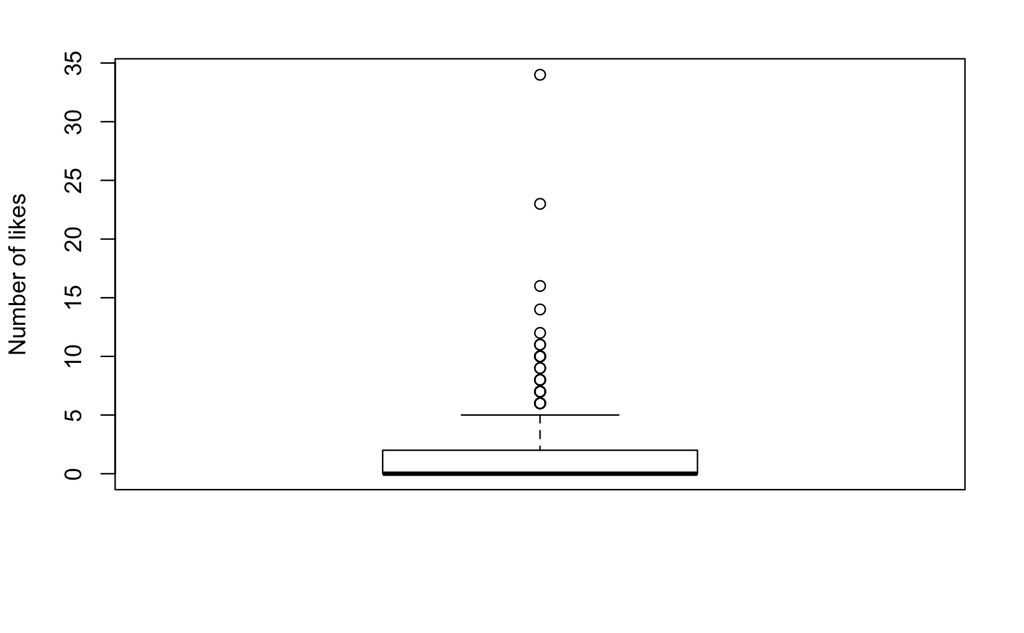

```r
# summary of the number of likes CodeClan tweets have using a boxplot
boxplot(code_clan_tweets$favorite_count, ylab = "Number of likes")
```

```r
outliers <- boxplot(code_clan_tweets$favorite_count, plot=FALSE)$out
print(outliers)
```

```
 [1]  7  9  6 12  7  6 10 23  7 14 34  8 10  6  8  8 11 10  7  9 10 10 16  6 11  7
```

3.Summarise the number of likes (stored in favorite_count) that CodeClan tweets have got. Don’t summarise when it was a quoted tweet (is_quote variable).

```r
code_clan_tweets %>%
  summarise(sum_of_likes = sum(favorite_count))
```

| sum_of_likes |
| --- |
| 446 |

```r
NA
```

```r
# likes excluding tweets where is_quote == TRUE
excluding_quoted_tweets <- code_clan_tweets %>%
  filter(is_quote == FALSE) %>%
  summarise(sum_of_likes = sum(favorite_count))

excluding_quoted_tweets
```

| sum_of_likes |
| --- |
| 425 |

```r
code_clan_tweets %>%
  filter(is_quote == FALSE & favorite_count > 0) %>%
  group_by(favorite_count) %>%
  count(favorite_count, sort = TRUE) %>%
  arrange(desc(favorite_count))
```

| favorite_count | n |
| --- | --- |
| 34 | 1 |
| 23 | 1 |
| 16 | 1 |
| 14 | 1 |
| 12 | 1 |
| 11 | 2 |
| 10 | 5 |
| 9 | 2 |
| 8 | 2 |
| 7 | 5 |

[output cut: 6 more lines]

```r
code_clan_tweets %>%
  filter(is_quote == FALSE & favorite_count > 0) %>%
  summarise(number_of_tweets_liked = n(), sum_of_all_likes = sum(favorite_count))
```

| number_of_tweets_liked | sum_of_all_likes |
| --- | --- |
| 89 | 425 |

4. Summarise the mean number of retweets (retweet_count), by the type of platform that was used to tweet (source).

```r
mean_retweets_by_platform <- code_clan_tweets %>%
  select(source, retweet_count) %>%
  group_by(source) %>%
  summarise(mean_retweets = mean(retweet_count))

mean_retweets_by_platform
```

| source | mean_retweets |
| --- | --- |
| Hootsuite Inc. | 1.428571 |
| Tweetbot for Mac | 4.000000 |
| TweetDeck | 5.000000 |
| Twitter for iPhone | 2.901235 |
| Twitter Web App | 2.436975 |
| Twitter Web Client | 2.363636 |

5. Count the number of likes by media type, and arrange them from most likes to least.

```r
code_clan_tweets %>%
  select(media_type, favorite_count) %>%
  filter(favorite_count > 0) %>%
  group_by(media_type) %>%
  count(favorite_count, sort = TRUE) %>%
  arrange(media_type, desc(favorite_count))
```

| media_type | favorite_count | n |
| --- | --- | --- |
| photo | 34 | 1 |
| photo | 23 | 1 |
| photo | 16 | 1 |
| photo | 14 | 1 |
| photo | 12 | 1 |
| photo | 11 | 2 |
| photo | 10 | 5 |
| photo | 9 | 2 |
| photo | 8 | 2 |
| photo | 7 | 4 |

[output cut: 13 more lines]

```r
NA
```

```r
likes_by_media_type <- code_clan_tweets %>%
  select(media_type, favorite_count) %>%
  filter(favorite_count > 0) %>%
  group_by(media_type) %>%
  summarise(sum(favorite_count))

likes_by_media_type
```

| media_type | sum(favorite_count) |
| --- | --- |
| photo | 371 |
| NA | 75 |

6. Find the mean number of characters a CodeClan tweet contains.

```r
# characters per tweet
mean_num_chrs_in_tweets <- code_clan_tweets %>%
  mutate(text_chr = str_count(text)) %>%
  summarise(mean_num_chrs_in_tweets = mean(text_chr))

mean_num_chrs_in_tweets
```

| mean_num_chrs_in_tweets |
| --- |
| 188.3718 |

7. Convert the dates in the created_at variable into ISO format, and store them in a new datetime variable. Get the months and store them in a new variable called `month`.

```r
library(lubridate)
code_clan_tweets <- code_clan_tweets %>%
  mutate(iso_date = dmy_hm(created_at)) %>%
  mutate(month = month(iso_date, label = TRUE))

code_clan_tweets[ 28:29]
```

| iso_date | month |
| --- | --- |
| 2019-05-23 08:32:00 | May |
| 2019-05-22 14:04:00 | May |
| 2019-05-22 14:01:00 | May |
| 2019-05-22 13:22:00 | May |
| 2019-05-22 10:10:00 | May |
| 2019-05-21 13:16:00 | May |
| 2019-05-21 12:41:00 | May |
| 2019-05-21 12:35:00 | May |
| 2019-05-21 12:35:00 | May |
| 2019-05-21 11:21:00 | May |

[output cut: 224 more lines]

8. Using your new month column, count the number retweets codeclan got in May vs April.

```r
counting_retweets_apr_may <- code_clan_tweets %>%
  select(retweet_count, month) %>%
  group_by(month) %>%
  summarise(count_of_retweets = n())

counting_retweets_apr_may
```

| month | count_of_retweets |
| --- | --- |
| Apr | 116 |
| May | 118 |

9. The `code_clan_info.csv` contains url and tweet info. Load this in, and join it to the `code_clan_tweets` data, so that you have a tweet url for wherever you have a tweet.

```r
code_clan_info <- read_csv("data/code_clan_info.csv")
code_clan_tweets_and_info <- code_clan_tweets %>%
  left_join(code_clan_info, by = "tweet_id")

code_clan_tweets_and_info
```

| tweet_id | user_id | created_at | screen_name | text | source | display_text_width | reply_to_status_id | reply_to_user_id | reply_to_screen_name | is_quote | is_retweet | favorite_count | retweet_count | quote_count | reply_count | hashtags | symbols | urls_url | urls_t.co | urls_expanded_url | media_type | retweet_source | retweet_favorite_count | retweet_retweet_count | retweet_user_id | retweet_location | iso_date | month | status_url | … |
| --- | --- | --- | --- | --- | --- | --- | --- | --- | --- | --- | --- | --- | --- | --- | --- | --- | --- | --- | --- | --- | --- | --- | --- | --- | --- | --- | --- | --- | --- | --- |
| 347 | 3250721351 | 23/05/19 08:32 | CodeClanScot | @CodeClanScot has arrived in the Highlands! https://t.co/IJT6zbhEBT via @YouTube | Twitter Web App | 100 | NA | NA | NA | FALSE | TRUE | 0 | 1 | NA | NA | NA | NA | youtu.be/r3970XRMgeg | https://t.co/IJT6zbhEBT | https://youtu.be/r3970XRMgeg | NA | Twitter for iPhone | 5 | 1 | 1.110000e+18 | Edinburgh, Scotland | 2019-05-23 08:32:00 | May | https://twitter.com/CodeClanScot/status/1131477871397081088 | … |
| 346 | 3250721351 | 22/05/19 14:04 | CodeClanScot | We talked to one of our grads, Alex, about what it was like coming to CodeClan and changing career ___ Read her story here: https://t.co/UuFLgOFmcB | Twitter Web App | 148 | NA | NA | NA | FALSE | FALSE | 5 | 1 | NA | NA | NA | NA | bit.ly/2Hw8T1e | https://t.co/UuFLgOFmcB | https://bit.ly/2Hw8T1e | NA | NA | NA | NA | NA | NA | 2019-05-22 14:04:00 | May | https://twitter.com/CodeClanScot/status/1131199199725477888 | … |
| 345 | 3250721351 | 22/05/19 14:01 | CodeClanScot | A week to go until our #Dundee Sourcing the Next Generation of Talent event - have you booked your place yet? Come along to hear from @eplacementscot @GA_Dundee @CodeClanScot and @OUScotland on how th… | Twitter Web App | 140 | NA | NA | NA | FALSE | TRUE | 0 | 5 | NA | NA | Dundee | NA | NA | NA | NA | NA | Hootsuite Inc. | 6 | 5 | 3.997880e+07 | Scotland | 2019-05-22 14:01:00 | May | https://twitter.com/CodeClanScot/status/1131198519769993217 | … |
| 344 | 3250721351 | 22/05/19 13:22 | CodeClanScot | New #tech means new business opportunities. Join @IngledewStephen, @C_Leaver, @MaMChannel, @GerryMcCusker, @DonaldMcL, @pollyp + more at #DigitalScotland19 for some exciting chats around #skills &amp;… | Twitter Web App | 140 | NA | NA | NA | FALSE | TRUE | 0 | 4 | NA | NA | tech | NA | NA | NA | NA | NA | Twitter Web Client | 6 | 4 | 3.288078e+09 | Edinburgh, Scotland | 2019-05-22 13:22:00 | May | https://twitter.com/CodeClanScot/status/1131188636991541248 | … |
| 343 | 3250721351 | 22/05/19 10:10 | CodeClanScot | Scotland needs Data Analysts! Learn how you can gain the skills to transform your career at our Data Analysis Information Evening this Thursday. book your free ticket here: https://t.co/0UDZFQaGeB htt… | Twitter Web App | 196 | NA | NA | NA | FALSE | FALSE | 3 | 1 | NA | NA | NA | NA | bit.ly/2JUmdy0 | https://t.co/0UDZFQaGeB | http://bit.ly/2JUmdy0 | photo | NA | NA | NA | NA | NA | 2019-05-22 10:10:00 | May | https://twitter.com/CodeClanScot/status/1131140312888483840 | … |
| 342 | 3250721351 | 21/05/19 13:16 | CodeClanScot | RT @TechmumsHQ: Congrats to our Edinburgh #techmums on graduating and well done to the amazing @CodeClanScot facilitators for running such a brilliant #techmumsClub #digitalskillsmatter #empoweringwom… | Twitter Web App | 140 | NA | NA | NA | FALSE | TRUE | 0 | 3 | NA | NA | techmums | NA | NA | NA | NA | NA | IFTTT | 8 | 3 | 9.439170e+08 | Chicago, IL | 2019-05-21 13:16:00 | May | https://twitter.com/CodeClanScot/status/1130824730263601153 | … |
| 341 | 3250721351 | 21/05/19 12:41 | CodeClanScot | @TechmumsHQ So proud of our #techmums ___ | Twitter Web App | 29 | 1.13e+18 | 1.875635e+09 | TechmumsHQ | FALSE | FALSE | 2 | 1 | NA | NA | techmums | NA | NA | NA | NA | NA | NA | NA | NA | NA | NA | 2019-05-21 12:41:00 | May | https://twitter.com/CodeClanScot/status/1130815974062678017 | … |
| 340 | 3250721351 | 21/05/19 12:35 | CodeClanScot | Congrats to our Edinburgh #techmums on graduating and well done to the amazing @CodeClanScot facilitators for running such a brilliant #techmumsClub #digitalskillsmatter #empoweringwomen #WomenInTech … | Twitter Web App | 139 | NA | NA | NA | FALSE | TRUE | 0 | 7 | NA | NA | techmums | NA | NA | NA | NA | NA | Twitter for iPhone | 17 | 7 | 1.875635e+09 | London, England | 2019-05-21 12:35:00 | May | https://twitter.com/CodeClanScot/status/1130814363667972096 | … |
| 339 | 3250721351 | 21/05/19 12:35 | CodeClanScot | Is finance holding you back from joining our Professional Software Development course? We\xeave released a deferred payment plan specifically for anyone looking to join our next Glasgow cohort on the … | Twitter Web App | 261 | NA | NA | NA | FALSE | FALSE | 2 | 1 | NA | NA | NA | NA | codeclan.com/courses/edaid-\xc4 | https://t.co/JNJBWZyO9o | https://codeclan.com/courses/edaid-apply/ | NA | NA | NA | NA | NA | NA | 2019-05-21 12:35:00 | May | https://twitter.com/CodeClanScot/status/1130814292566134789 | … |
| 338 | 3250721351 | 21/05/19 11:21 | CodeClanScot | Scotland needs data analysts! Find out how you can gain the skills to transform your career this Thursday at our Data Analysis Information Evening. Find out more about the event and book your free tic… | Twitter Web App | 233 | NA | NA | NA | FALSE | FALSE | 4 | 2 | NA | NA | NA | NA | bit.ly/2JUmdy0 | https://t.co/PmruJ6rao4 | https://bit.ly/2JUmdy0 | photo | NA | NA | NA | NA | NA | 2019-05-21 11:21:00 | May | https://twitter.com/CodeClanScot/status/1130795810659209216 | … |

[output cut: 224 more lines]

10. From your new joined data, create a variable which has all the hashtags in lowercase for analysis.

```r
code_clan_tweets_and_info_hashtag <- code_clan_tweets_and_info %>%
  mutate(lower_hashtags = str_to_lower(hashtags))

code_clan_tweets_and_info_hashtag[, 44]
```

| lower_hashtags |
| --- |
| NA |
| NA |
| dundee |
| tech |
| NA |
| techmums |
| techmums |
| techmums |
| NA |
| NA |

[output cut: 224 more lines]

11. Some tweets have more than one hashtag, denoted by the c() expression at the start of the string. Use the substr and str_detect functions to create a tibble where the first letter of the string begins with a c.

```r
#substr(code_clan_tweets_and_info_hashtag$lower_hashtags, 1, 1)
#str_detect(code_clan_tweets_and_info_hashtag$lower_hashtags, "^c[a-z]")
str_extract(code_clan_tweets_and_info_hashtag$lower_hashtags, "^c[a-z0-9._()a-z]+")
```

```
  [1] NA              NA              NA              NA              NA
  [6] NA              NA              NA              NA              NA
 [11] NA              NA              NA              NA              NA
 [16] NA              NA              NA              NA              NA
 [21] NA              NA              NA              NA              NA
 [26] "cx"            NA              NA              NA              NA
 [31] NA              NA              "codeclanlife"  NA              NA
 [36] NA              "c("            NA              "c("            "c("
 [41] NA              NA              "c("            NA              NA
 [46] "c("            NA              NA              NA              "c("
 [51] NA              NA              "c("            NA              NA
 [56] "c("            "c("            "c("            NA              "c("
 [61] NA              NA              "c("            NA              "c("
 [66] NA              "c("            NA              NA              NA
 [71] NA              NA              NA              NA              NA
```

[output cut: 32 more lines]

^c[a-z0-9._()a-z0-9._)]

```r
pattern <- "^c[a-z0-9()]+\\\"+[a-z0-9._,)]+\\\""

as.tibble(str_extract(code_clan_tweets_and_info_hashtag$lower_hashtags, pattern)) %>%
  na.omit()
```

| value |
| --- |
| c("javascript" |
| c("a11y" |
| c("tech" |
| c("refugees" |
| c("impactsummit19" |
| c("vr" |
| c("wellness" |
| c("impactsummit19" |
| c("impactsummit19" |
| c("impactsummit19" |

[output cut: 39 more lines]

12. Use the str_extract function to find all cases where a tweet mentions edinburgh anywhere in it. How many mentions of Edinburgh are there in CodeClan’s tweets? Hint: you may need to make sure your tweets are all the same case before searching.

```r
code_clan_tweets_and_info <- code_clan_tweets_and_info %>%
  mutate(lower_text = str_to_lower(text))

code_clan_tweets_and_info[, 44]
```

| lower_text |
| --- |
| @codeclanscot has arrived in the highlands! https://t.co/ijt6zbhebt via @youtube |
| we talked to one of our grads, alex, about what it was like coming to codeclan and changing career ___ read her story here: https://t.co/uuflgofmcb |
| a week to go until our #dundee sourcing the next generation of talent event - have you booked your place yet? come along to hear from @eplacementscot @ga_dundee @codeclanscot and @ouscotland on how th… |
| new #tech means new business opportunities. join @ingledewstephen, @c_leaver, @mamchannel, @gerrymccusker, @donaldmcl, @pollyp + more at #digitalscotland19 for some exciting chats around #skills &amp;… |
| scotland needs data analysts! learn how you can gain the skills to transform your career at our data analysis information evening this thursday. book your free ticket here: https://t.co/0udzfqageb htt… |
| rt @techmumshq: congrats to our edinburgh #techmums on graduating and well done to the amazing @codeclanscot facilitators for running such a brilliant #techmumsclub #digitalskillsmatter #empoweringwom… |
| @techmumshq so proud of our #techmums ___ |
| congrats to our edinburgh #techmums on graduating and well done to the amazing @codeclanscot facilitators for running such a brilliant #techmumsclub #digitalskillsmatter #empoweringwomen #womenintech … |
| is finance holding you back from joining our professional software development course? we\xeave released a deferred payment plan specifically for anyone looking to join our next glasgow cohort on the … |
| scotland needs data analysts! find out how you can gain the skills to transform your career this thursday at our data analysis information evening. find out more about the event and book your free tic… |

[output cut: 224 more lines]

```r
str_extract_all(code_clan_tweets_and_info$lower_text, "edinburgh")
```

```
[[1]]
character(0)

[[2]]
character(0)

[[3]]
character(0)

[[4]]
character(0)

[[5]]
character(0)

[[6]]
[1] "edinburgh"

[[7]]
character(0)

[[8]]
[1] "edinburgh"

[[9]]
character(0)

[[10]]
character(0)

[[11]]
character(0)

[[12]]
[1] "edinburgh"

[[13]]
character(0)

[[14]]
```

[output cut: 646 more lines]

```

[[230]]
character(0)

[[231]]
character(0)

[[232]]
character(0)

[[233]]
character(0)

[[234]]
character(0)
```

```r
sum(str_count(code_clan_tweets_and_info$lower_text, "edinburgh"))
```

```
[1] 37
```

13. Use str_extract_all with a regular expression to find out which users CodeClan have been tweeting. Hint: think about all the different characters which could be in a username

```r
pattern <- "[_A-Za-z0-9_]+"

str_extract_all(code_clan_tweets_and_info$reply_to_screen_name, pattern)
```

```
[[1]]
[1] NA

[[2]]
[1] NA

[[3]]
[1] NA

[[4]]
[1] NA

[[5]]
[1] NA

[[6]]
[1] NA

[[7]]
[1] "TechmumsHQ"

[[8]]
[1] NA

[[9]]
[1] NA

[[10]]
[1] NA

[[11]]
[1] "_LaurenAllison_"

[[12]]
[1] NA

[[13]]
[1] NA

[[14]]
```

[output cut: 646 more lines]

```

[[230]]
[1] NA

[[231]]
[1] NA

[[232]]
[1] NA

[[233]]
[1] NA

[[234]]
[1] NA
```

Extensions: Tasks 14. codeclan_info has tweet url (status_url) stored in a string. Save the numeric substring part of the string in a new variable called status_url_number

```r
#code_clan_info

separate(code_clan_info, status_url, c("status_url", "status_url_number"), sep = "([^/]+)/?$")
```

| tweet_id | status_url | status_url_number | name | location | description | url | protected | followers_count | friends_count | listed_count | statuses_count | favourites_count | account_created_at | verified | profile_url |
| --- | --- | --- | --- | --- | --- | --- | --- | --- | --- | --- | --- | --- | --- | --- | --- |
| 347 | https://twitter.com/CodeClanScot/status/ |  | CodeClan | Edinburgh & Glasgow & Inverness | Change your career through our immersive full time courses or up-skill through our range of short courses. Join our team and hire job-ready talent! | https://t.co/cT46pkkCBO | FALSE | 5835 | 2632 | 119 | 6103 | 4443 | 13/05/15 08:21 | FALSE | https://t.co/cT46pkkCBO |
| 346 | https://twitter.com/CodeClanScot/status/ |  | CodeClan | Edinburgh & Glasgow & Inverness | Change your career through our immersive full time courses or up-skill through our range of short courses. Join our team and hire job-ready talent! | https://t.co/cT46pkkCBO | FALSE | 5835 | 2632 | 119 | 6103 | 4443 | 13/05/15 08:21 | FALSE | https://t.co/cT46pkkCBO |
| 345 | https://twitter.com/CodeClanScot/status/ |  | CodeClan | Edinburgh & Glasgow & Inverness | Change your career through our immersive full time courses or up-skill through our range of short courses. Join our team and hire job-ready talent! | https://t.co/cT46pkkCBO | FALSE | 5835 | 2632 | 119 | 6103 | 4443 | 13/05/15 08:21 | FALSE | https://t.co/cT46pkkCBO |
| 344 | https://twitter.com/CodeClanScot/status/ |  | CodeClan | Edinburgh & Glasgow & Inverness | Change your career through our immersive full time courses or up-skill through our range of short courses. Join our team and hire job-ready talent! | https://t.co/cT46pkkCBO | FALSE | 5835 | 2632 | 119 | 6103 | 4443 | 13/05/15 08:21 | FALSE | https://t.co/cT46pkkCBO |
| 343 | https://twitter.com/CodeClanScot/status/ |  | CodeClan | Edinburgh & Glasgow & Inverness | Change your career through our immersive full time courses or up-skill through our range of short courses. Join our team and hire job-ready talent! | https://t.co/cT46pkkCBO | FALSE | 5835 | 2632 | 119 | 6103 | 4443 | 13/05/15 08:21 | FALSE | https://t.co/cT46pkkCBO |
| 342 | https://twitter.com/CodeClanScot/status/ |  | CodeClan | Edinburgh & Glasgow & Inverness | Change your career through our immersive full time courses or up-skill through our range of short courses. Join our team and hire job-ready talent! | https://t.co/cT46pkkCBO | FALSE | 5835 | 2632 | 119 | 6103 | 4443 | 13/05/15 08:21 | FALSE | https://t.co/cT46pkkCBO |
| 341 | https://twitter.com/CodeClanScot/status/ |  | CodeClan | Edinburgh & Glasgow & Inverness | Change your career through our immersive full time courses or up-skill through our range of short courses. Join our team and hire job-ready talent! | https://t.co/cT46pkkCBO | FALSE | 5835 | 2632 | 119 | 6103 | 4443 | 13/05/15 08:21 | FALSE | https://t.co/cT46pkkCBO |
| 340 | https://twitter.com/CodeClanScot/status/ |  | CodeClan | Edinburgh & Glasgow & Inverness | Change your career through our immersive full time courses or up-skill through our range of short courses. Join our team and hire job-ready talent! | https://t.co/cT46pkkCBO | FALSE | 5835 | 2632 | 119 | 6103 | 4443 | 13/05/15 08:21 | FALSE | https://t.co/cT46pkkCBO |
| 339 | https://twitter.com/CodeClanScot/status/ |  | CodeClan | Edinburgh & Glasgow & Inverness | Change your career through our immersive full time courses or up-skill through our range of short courses. Join our team and hire job-ready talent! | https://t.co/cT46pkkCBO | FALSE | 5835 | 2632 | 119 | 6103 | 4443 | 13/05/15 08:21 | FALSE | https://t.co/cT46pkkCBO |
| 338 | https://twitter.com/CodeClanScot/status/ |  | CodeClan | Edinburgh & Glasgow & Inverness | Change your career through our immersive full time courses or up-skill through our range of short courses. Join our team and hire job-ready talent! | https://t.co/cT46pkkCBO | FALSE | 5835 | 2632 | 119 | 6103 | 4443 | 13/05/15 08:21 | FALSE | https://t.co/cT46pkkCBO |

[output cut: 224 more lines]

```r
code_clan_info_with_url_number <- code_clan_info %>%
  mutate(status_url_number = str_sub(code_clan_info$status_url, -19, -1))
code_clan_info_with_url_number[, 16]
```

| status_url_number |
| --- |
| 1131477871397081088 |
| 1131199199725477888 |
| 1131198519769993217 |
| 1131188636991541248 |
| 1131140312888483840 |
| 1130824730263601153 |
| 1130815974062678017 |
| 1130814363667972096 |
| 1130814292566134789 |
| 1130795810659209216 |

[output cut: 224 more lines]

```r
str_sub(code_clan_info$status_url, -19, -1)
```

```
  [1] "1131477871397081088" "1131199199725477888" "1131198519769993217"
  [4] "1131188636991541248" "1131140312888483840" "1130824730263601153"
  [7] "1130815974062678017" "1130814363667972096" "1130814292566134789"
 [10] "1130795810659209216" "1130776345863233536" "1130776181710741505"
 [13] "1130482539683110912" "1130461794957500417" "1130453287117971456"
 [16] "1130453006896553989" "1130440208137297920" "1130438861593763840"
 [19] "1130416635750297600" "1130395217813745664" "1130395041254518784"
 [22] "1130392750975803392" "1130389467376832513" "1129748808139759616"
 [25] "1129431774206017536" "1129416802205876224" "1129410758847148033"
 [28] "1129410747677720577" "1129410746469822465" "1129383207969992705"
 [31] "1129383084762247177" "1129295676825886721" "1129073528559546369"
 [34] "1129017480544968704" "1129009657626931207" "1129001203734601728"
 [37] "1128976684634562561" "1128953925741240322" "1128941881403084800"
 [40] "1128673425210400768" "1128672917494161409" "1128660601360801792"
 [43] "1128655726854004736" "1128653076544540673" "1128650783845691394"
```

[output cut: 63 more lines]

```r
pattern <- "([^/]+)/?$"
str_extract(code_clan_info$status_url, pattern)
```

```
  [1] "1131477871397081088" "1131199199725477888" "1131198519769993217"
  [4] "1131188636991541248" "1131140312888483840" "1130824730263601153"
  [7] "1130815974062678017" "1130814363667972096" "1130814292566134789"
 [10] "1130795810659209216" "1130776345863233536" "1130776181710741505"
 [13] "1130482539683110912" "1130461794957500417" "1130453287117971456"
 [16] "1130453006896553989" "1130440208137297920" "1130438861593763840"
 [19] "1130416635750297600" "1130395217813745664" "1130395041254518784"
 [22] "1130392750975803392" "1130389467376832513" "1129748808139759616"
 [25] "1129431774206017536" "1129416802205876224" "1129410758847148033"
 [28] "1129410747677720577" "1129410746469822465" "1129383207969992705"
 [31] "1129383084762247177" "1129295676825886721" "1129073528559546369"
 [34] "1129017480544968704" "1129009657626931207" "1129001203734601728"
 [37] "1128976684634562561" "1128953925741240322" "1128941881403084800"
 [40] "1128673425210400768" "1128672917494161409" "1128660601360801792"
 [43] "1128655726854004736" "1128653076544540673" "1128650783845691394"
```

[output cut: 63 more lines]

15. Use the str_replace function to replace the url numbers in the status_url_number string with a the word HIDDEN_URL

```r
#code_clan_info_with_url_number[, 16]
replacement_vector <- replicate(234, "HIDDEN_UL")
replacement_vector
```

```
  [1] "HIDDEN_UL" "HIDDEN_UL" "HIDDEN_UL" "HIDDEN_UL" "HIDDEN_UL" "HIDDEN_UL"
  [7] "HIDDEN_UL" "HIDDEN_UL" "HIDDEN_UL" "HIDDEN_UL" "HIDDEN_UL" "HIDDEN_UL"
 [13] "HIDDEN_UL" "HIDDEN_UL" "HIDDEN_UL" "HIDDEN_UL" "HIDDEN_UL" "HIDDEN_UL"
 [19] "HIDDEN_UL" "HIDDEN_UL" "HIDDEN_UL" "HIDDEN_UL" "HIDDEN_UL" "HIDDEN_UL"
 [25] "HIDDEN_UL" "HIDDEN_UL" "HIDDEN_UL" "HIDDEN_UL" "HIDDEN_UL" "HIDDEN_UL"
 [31] "HIDDEN_UL" "HIDDEN_UL" "HIDDEN_UL" "HIDDEN_UL" "HIDDEN_UL" "HIDDEN_UL"
 [37] "HIDDEN_UL" "HIDDEN_UL" "HIDDEN_UL" "HIDDEN_UL" "HIDDEN_UL" "HIDDEN_UL"
 [43] "HIDDEN_UL" "HIDDEN_UL" "HIDDEN_UL" "HIDDEN_UL" "HIDDEN_UL" "HIDDEN_UL"
 [49] "HIDDEN_UL" "HIDDEN_UL" "HIDDEN_UL" "HIDDEN_UL" "HIDDEN_UL" "HIDDEN_UL"
 [55] "HIDDEN_UL" "HIDDEN_UL" "HIDDEN_UL" "HIDDEN_UL" "HIDDEN_UL" "HIDDEN_UL"
 [61] "HIDDEN_UL" "HIDDEN_UL" "HIDDEN_UL" "HIDDEN_UL" "HIDDEN_UL" "HIDDEN_UL"
 [67] "HIDDEN_UL" "HIDDEN_UL" "HIDDEN_UL" "HIDDEN_UL" "HIDDEN_UL" "HIDDEN_UL"
 [73] "HIDDEN_UL" "HIDDEN_UL" "HIDDEN_UL" "HIDDEN_UL" "HIDDEN_UL" "HIDDEN_UL"
 [79] "HIDDEN_UL" "HIDDEN_UL" "HIDDEN_UL" "HIDDEN_UL" "HIDDEN_UL" "HIDDEN_UL"
 [85] "HIDDEN_UL" "HIDDEN_UL" "HIDDEN_UL" "HIDDEN_UL" "HIDDEN_UL" "HIDDEN_UL"
```

[output cut: 24 more lines]

```r
#code_clan_info_with_url_number %>%
str_replace_all(code_clan_info_with_url_number$status_url_number, replacement_vector)
```

```
Error in fix_replacement(replacement) :
  argument "replacement" is missing, with no default
```

16. Use str_detect to see which tweets don’t include a shortened link (https://t.co/**********)

```r
str_pattern <- "[https://]+[t.co]+"

result <- str_detect(code_clan_tweets$urls_t.co, str_pattern, negate = TRUE)
#str_extract(code_clan_tweets$urls_t.co, str_pattern)
result
```

```
  [1] FALSE FALSE    NA    NA FALSE    NA    NA    NA FALSE FALSE    NA    NA FALSE
 [14]    NA    NA    NA    NA    NA    NA    NA    NA FALSE    NA FALSE FALSE    NA
 [27] FALSE    NA    NA    NA    NA FALSE    NA    NA FALSE    NA    NA    NA    NA
 [40]    NA    NA    NA    NA    NA    NA    NA    NA FALSE    NA    NA    NA    NA
 [53]    NA FALSE    NA    NA    NA    NA    NA    NA    NA FALSE    NA    NA    NA
 [66]    NA    NA FALSE    NA    NA    NA FALSE FALSE    NA    NA    NA    NA FALSE
 [79] FALSE    NA    NA    NA FALSE    NA    NA FALSE    NA    NA    NA    NA FALSE
 [92] FALSE FALSE    NA FALSE    NA    NA FALSE    NA FALSE    NA FALSE    NA    NA
[105]    NA    NA    NA FALSE    NA    NA FALSE FALSE    NA    NA FALSE    NA FALSE
[118] FALSE FALSE FALSE FALSE    NA    NA    NA    NA    NA    NA FALSE    NA    NA
[131]    NA    NA    NA    NA    NA    NA    NA    NA FALSE    NA FALSE    NA FALSE
[144] FALSE    NA    NA    NA    NA    NA    NA    NA    NA    NA    NA    NA    NA
[157] FALSE    NA    NA    NA    NA FALSE    NA    NA FALSE    NA    NA    NA    NA
[170]    NA FALSE FALSE    NA FALSE    NA    NA    NA    NA    NA    NA    NA    NA
[183]    NA    NA    NA    NA FALSE    NA    NA    NA    NA    NA FALSE    NA    NA
[196]    NA FALSE    NA    NA    NA    NA    NA    NA FALSE    NA FALSE FALSE FALSE
[209] FALSE    NA FALSE    NA FALSE FALSE FALSE FALSE FALSE FALSE    NA FALSE FALSE
[222]    NA    NA    NA FALSE    NA    NA    NA    NA    NA FALSE FALSE FALSE    NA
```

```r
sum(is.na((result)))
```

```
[1] 164
```